# Part II - (Ford GoBike Dataset Exploration)

## by (Joan Njeri)

## Investigation Overview

> Key focus for this analysis is identify features that affect bike riding and find trend and pattern of different user types behaviour when using Ford GoBike

## Dataset Overview

> This data set includes information about individual rides made in a bike-sharing system covering the greater San Francisco Bay area. The data includes information about 183,000 rides made in a bike-sharing system covering the greater San Francisco Bay area and 16 fetatures that includes 'duration_sec', 'start_time', 'end_time', 'start_station_id','start_station_name'and some additional variable

### Plot the distribution of the duration_min

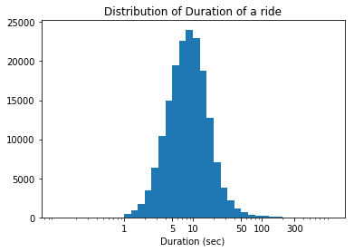

### Plot the distribution of the riders age

> Age distribution is more concentrated between 25 to 40 years old

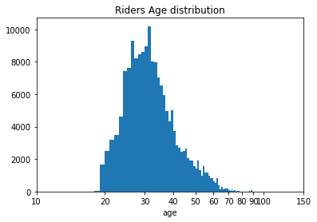

### Plot the distribution of the gender

> > The 74.61 percent of the bike riders are male

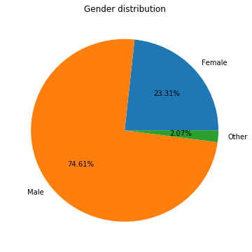

### Plot the correlation between duration and age

> Duration and age has a weak negative relationship indicating the older the user, the shorter the duration of the trip

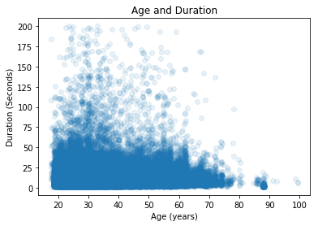

### Plot the distribution user type and gender

> Males subscribers have the highest number of bike riders

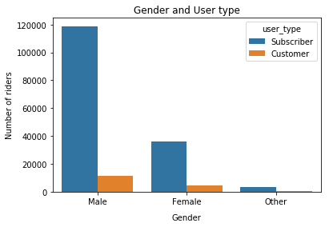

### Plot the Relationship between age, duration and gender

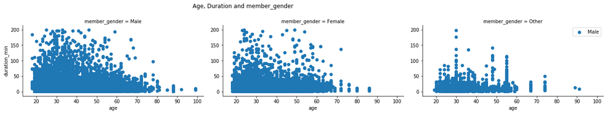